# CS6700: Reinforcement Learning

## Tutorial 4: SARSA and Q-Learning

## Gautham Govind A, EE19B022

```python
import numpy as np
import matplotlib.pyplot as plt
from tqdm import tqdm
from IPython.display import clear_output
%matplotlib inline
```

# Problem Statement

In this section we will implement tabular SARSA and Q-learning algorithms for a grid world navigation task.

## Environment details

The agent can move from one grid coordinate to one of its adjacent grids using one of the four actions: UP, DOWN, LEFT and RIGHT. The goal is to go from a randomly assigned starting position to goal position.

Actions that can result in taking the agent off the grid will not yield any effect. Lets look at the environment.

```python
DOWN = 0
UP = 1
LEFT = 2
RIGHT = 3
actions = [DOWN, UP, LEFT, RIGHT]
```

Let us construct a grid in a text file.

```python
from google.colab import drive
drive.mount('/content/drive')
```

```python
%%shell
cd drive/MyDrive/CS6700/CS6700_Tutorial_4_QLearning_SARSA
cat grid_world2.txt
```

```
0 0 0 0 0 0 0 0 0 0 0 0 0 0 0 0 0 0 0 0 0 0 0
0 0 0 0 0 0 0 0 0 0 0 0 0 0 0 0 0 0 0 0 0 0 0
0 0 0 0 0 0 0 0 0 0 0 0 0 0 0 0 0 0 0 0 0 0 0
1 1 1 1 1 1 1 1 1 1 1 1 1 0 0 0 0 0 0 0 0 0 0
1 1 1 1 1 1 1 1 1 1 1 1 1 0 0 0 0 0 0 0 0 0 0
1 1 1 1 1 1 1 1 1 1 1 1 1 0 0 0 0 0 0 0 0 0 0
1 1 1 1 1 1 2 2 2 1 1 1 1 0 0 0 0 0 0 0 0 0 0
0 0 0 1 1 1 2 2 2 1 1 1 1 0 0 0 0 0 0 0 0 0 0
0 0 0 1 1 1 2 2 2 1 1 1 1 0 0 0 0 0 0 0 0 0 0
0 0 0 1 1 1 2 2 2 1 1 1 1 0 0 0 0 0 0 0 0 0 0
0 0 0 1 1 1 2 2 2 1 1 1 1 0 0 0 0 0 0 0 0 0 0
0 0 0 1 1 1 2 2 2 1 1 1 1 0 0 0 0 0 0 0 0 0 0
0 0 0 1 1 1 1 1 1 1 1 1 1 0 0 0 0 0 0 0 0 0 0
0 0 0 0 0 0 0 0 0 0 0 0 0 0 0 0 0 0 0 0 0 0 0
0 0 0 0 0 0 0 0 0 0 0 0 0 0 0 0 0 0 0 0 0 0 0
0 0 0 0 0 0 0 0 0 0 0 0 0 0 0 0 0 0 0 0 0 0 0
0 0 0 0 0 0 0 0 0 0 0 0 0 0 0 0 0 0 0 0 0 0 0
```

This is a $17\times 23$ grid. The reward when an agent goes to a cell is negative of the value in that position in the text file (except if it is the goal cell). We will define the goal reward as 100. We will also fix the maximum episode length to 10000.

Now let's plot the grid world.

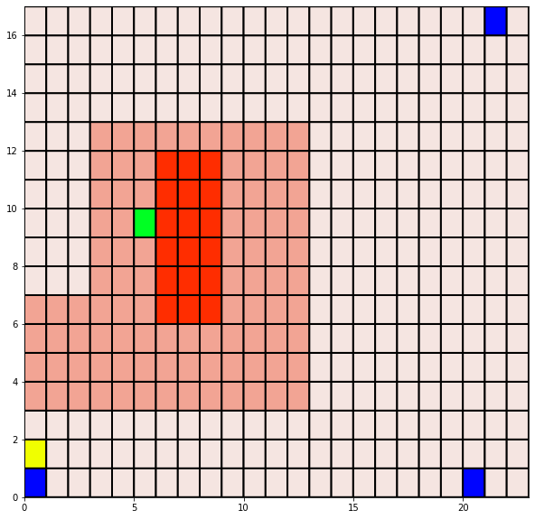

```python
world = 'grid_world2.txt'
goal_reward = 100
start_states = [(0,0), (0,20), (16,21)]
goal_states=[(9,5)]
max_steps=10000

from grid_world import GridWorldEnv, GridWorldWindyEnv

env = GridWorldEnv(world, goal_reward=goal_reward, start_states=start_states, goal_states=goal_states,
                max_steps=max_steps, action_fail_prob=0.2)
plt.figure(figsize=(10, 10))
# Go UP
env.step(UP)
env.render(ax=plt, render_agent=True)
```

### Legend

- *Blue* is the **start state**.
- *Green* is the **goal state**.
- *Yellow* is current **state of the agent**.
- *Redness* denotes the extent of **negative reward**.

### Q values

We can use a 3D array to represent Q values. The first two indices are X, Y coordinates and last index is the action.

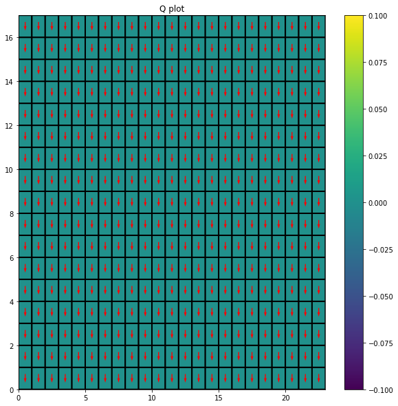

```
(17, 23, 4)
```

```python
from grid_world import plot_Q

Q = np.zeros((env.grid.shape[0], env.grid.shape[1], len(env.action_space)))

plot_Q(Q)

Q.shape
```

### Exploration strategies

1. Epsilon-greedy
2. Softmax

```python
from scipy.special import softmax

seed = 42
rg = np.random.RandomState(seed)

# Epsilon greedy
def choose_action_epsilon(Q, state, epsilon, rg=rg):
    if ( np.random.rand() < epsilon ): # TODO: eps greedy condition
        return np.random.choice(np.array([0, 1, 2, 3]))
    else:
        return np.argmax(Q[state[0], state[1], :])# TODO: return best action

# Softmax
def choose_action_softmax(Q, state, rg=rg):
    return np.random.choice(np.array([0, 1, 2, 3]), p = softmax(Q[state[0], state[1], :]))
```

## SARSA

Now we implement the SARSA algorithm.

Recall the update rule for SARSA: \begin{equation} Q(s_t,a_t) \leftarrow Q(s_t, a_t) + \alpha[r_t + \gamma Q(s_{t+1}, a_{t+1}) - Q(s_t, a_t)] \end{equation}

### Hyperparameters

So we have som hyperparameters for the algorithm:

- $\alpha$
- number of *episodes*.
- $\epsilon$: For epsilon greedy exploration

```python
# initialize Q-value
Q = np.zeros((env.grid.shape[0], env.grid.shape[1], len(env.action_space)))

alpha0 = 0.4
gamma = 0.9
episodes = 10000
epsilon0 = 0.1
```

Let's implement SARSA

```python
print_freq = 100

def sarsa(env, Q, gamma = 0.9, plot_heat = False, choose_action = choose_action_softmax):

    episode_rewards = np.zeros(episodes)
    steps_to_completion = np.zeros(episodes)
    if plot_heat:
        clear_output(wait=True)
        plot_Q(Q)
    epsilon = epsilon0
    alpha = alpha0
    for ep in tqdm(range(episodes)):
        tot_reward, steps = 0, 0

        # Reset environment
        state = env.reset()
        action = choose_action(Q, state)
        done = False
        while not done:
            state_next, reward, done = env.step(action)
            action_next = choose_action(Q, state_next)

            Q[state[0], state[1], action] = Q[state[0], state[1], action] + alpha0*(reward + gamma*Q[state_next[0], state_next[1], action_next] - Q[state[0], state[1], action])

            tot_reward += reward
            steps += 1

            state, action = state_next, action_next

        episode_rewards[ep] = tot_reward
        steps_to_completion[ep] = steps

        if (ep+1)%print_freq == 0 and plot_heat:
            clear_output(wait=True)
            plot_Q(Q, message = "Episode %d: Reward: %f, Steps: %.2f, Qmax: %.2f, Qmin: %.2f"%(ep+1, np.mean(episode_rewards[ep-print_freq+1:ep]),
                                                                           np.mean(steps_to_completion[ep-print_freq+1:ep]),
                                                                           Q.max(), Q.min()))

    return Q, episode_rewards, steps_to_completion
```

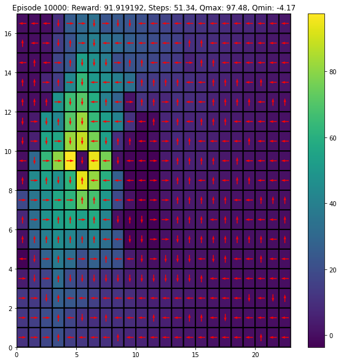

```python
Q, rewards, steps = sarsa(env, Q, gamma = gamma, plot_heat=True, choose_action= choose_action_softmax)
```

### Visualizing the policy

Now let's see the agent in action. Run the below cell (as many times) to render the policy;

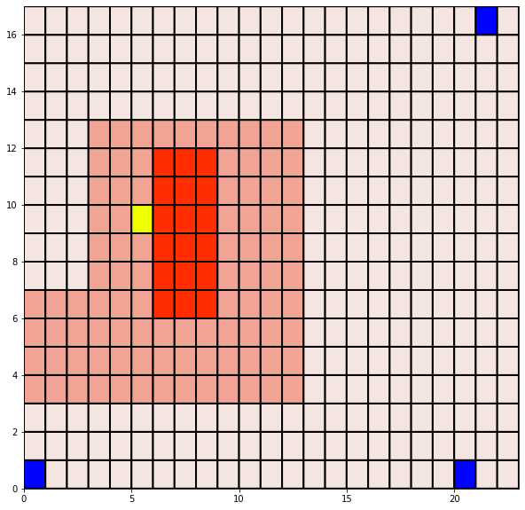

```
Steps: 23, Total Reward: 77
```

```python
from time import sleep

state = env.reset()
done = False
steps = 0
tot_reward = 0
while not done:
    clear_output(wait=True)
    state, reward, done = env.step(Q[state[0], state[1]].argmax())
    plt.figure(figsize=(10, 10))
    env.render(ax=plt, render_agent=True)
    plt.show()
    steps += 1
    tot_reward += reward
    sleep(0.2)
print("Steps: %d, Total Reward: %d"%(steps, tot_reward))
```

### Analyzing performance of the policy

We use two metrics to analyze the policies:

1. Average steps to reach the goal
2. Total rewards from the episode

To ensure, we account for randomness in environment and algorithm (say when using epsilon-greedy exploration), we run the algorithm for multiple times and use the average of values over all runs.

```python
num_expts = 5
reward_avgs, steps_avgs = [], []

for i in range(num_expts):
    print("Experiment: %d"%(i+1))
    Q = np.zeros((env.grid.shape[0], env.grid.shape[1], len(env.action_space)))
    rg = np.random.RandomState(i)

    Q, rewards, steps = sarsa(env, Q, gamma = gamma, plot_heat=False, choose_action= choose_action_softmax)
    reward_avgs.append(rewards)
    steps_avgs.append(steps)

    # TODO: run sarsa, store metrics
```

```
Experiment: 1
```

```
Experiment: 2
```

```
Experiment: 3
```

```
Experiment: 4
```

```
Experiment: 5
```

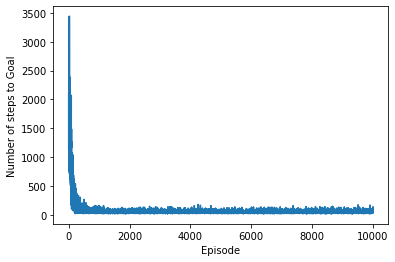

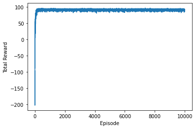

```python
plt.figure()
plt.plot(list(range(10000)), np.mean(np.array(steps_avgs), axis = 0))
plt.xlabel('Episode')
plt.ylabel('Number of steps to Goal')
plt.show()

plt.figure()
plt.plot(list(range(10000)), np.mean(np.array(reward_avgs), axis = 0))
plt.xlabel('Episode')
plt.ylabel('Total Reward')
plt.show()
```

## Q-Learning

Now, implement the Q-Learning algorithm as an exercise.

Recall the update rule for Q-Learning: \begin{equation} Q(s_t,a_t) \leftarrow Q(s_t, a_t) + \alpha[r_t + \gamma \max_a Q(s_{t+1}, a) - Q(s_t, a_t)] \end{equation}

Visualize and compare results with SARSA.

```python
# initialize Q-value
Q = np.zeros((env.grid.shape[0], env.grid.shape[1], len(env.action_space)))

alpha0 = 0.4
gamma = 0.9
episodes = 10000
epsilon0 = 0.1
```

```python
print_freq = 100

def qlearning(env, Q, gamma = 0.9, plot_heat = False, choose_action = choose_action_softmax):

    episode_rewards = np.zeros(episodes)
    steps_to_completion = np.zeros(episodes)
    if plot_heat:
        clear_output(wait=True)
        plot_Q(Q)
    epsilon = epsilon0
    alpha = alpha0
    for ep in tqdm(range(episodes)):
        tot_reward, steps = 0, 0

        # Reset environment
        state = env.reset()
        action = choose_action(Q, state)
        done = False
        while not done:
            state_next, reward, done = env.step(action)
            action_next = choose_action(Q, state_next)

            # TODO: update equation

            Q[state[0], state[1], action] = Q[state[0], state[1], action] + alpha0*(reward + gamma*np.max(Q[state_next[0], state_next[1], :]) - Q[state[0], state[1], action])

            tot_reward += reward
            steps += 1

            state, action = state_next, action_next

        episode_rewards[ep] = tot_reward
        steps_to_completion[ep] = steps

        if (ep+1)%print_freq == 0 and plot_heat:
            clear_output(wait=True)
            plot_Q(Q, message = "Episode %d: Reward: %f, Steps: %.2f, Qmax: %.2f, Qmin: %.2f"%(ep+1, np.mean(episode_rewards[ep-print_freq+1:ep]),
                                                                           np.mean(steps_to_completion[ep-print_freq+1:ep]),
                                                                           Q.max(), Q.min()))

    return Q, episode_rewards, steps_to_completion
```

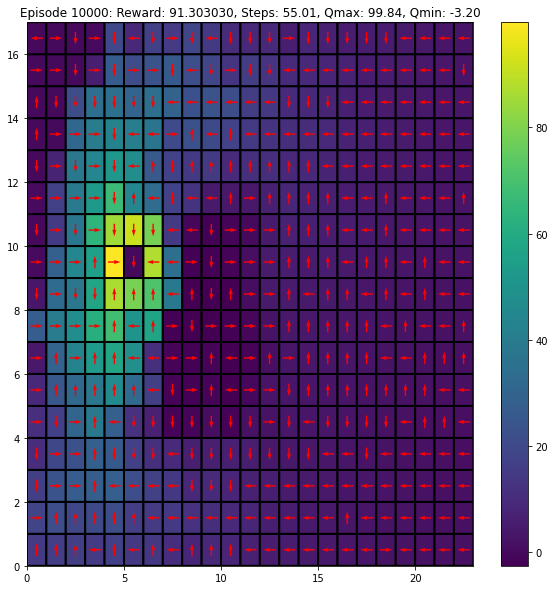

```python
Q, rewards, steps = qlearning(env, Q, gamma = gamma, plot_heat=True, choose_action= choose_action_softmax)
```

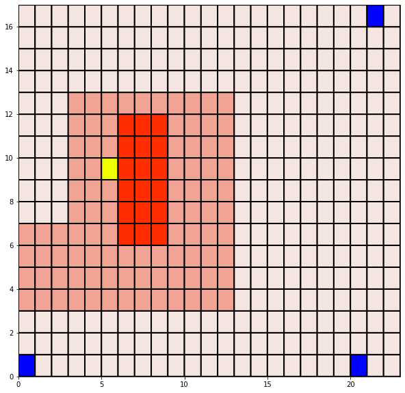

```
Steps: 36, Total Reward: 92
```

```python
from time import sleep

state = env.reset()
done = False
steps = 0
tot_reward = 0
while not done:
    clear_output(wait=True)
    state, reward, done = env.step(Q[state[0], state[1]].argmax())
    plt.figure(figsize=(10, 10))
    env.render(ax=plt, render_agent=True)
    plt.show()
    steps += 1
    tot_reward += reward
    sleep(0.2)
print("Steps: %d, Total Reward: %d"%(steps, tot_reward))
```

```python
num_expts = 5
reward_avgs, steps_avgs = [], []

for i in range(num_expts):
    print("Experiment: %d"%(i+1))
    Q = np.zeros((env.grid.shape[0], env.grid.shape[1], len(env.action_space)))
    rg = np.random.RandomState(i)

    Q, rewards, steps = qlearning(env, Q, gamma = gamma, plot_heat=False, choose_action= choose_action_softmax)
    reward_avgs.append(rewards)
    steps_avgs.append(steps)
    # TODO: run qlearning, store metrics
```

```
Experiment: 1
```

```
Experiment: 2
```

```
Experiment: 3
```

```
Experiment: 4
```

```
Experiment: 5
```

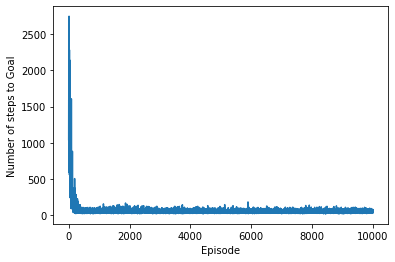

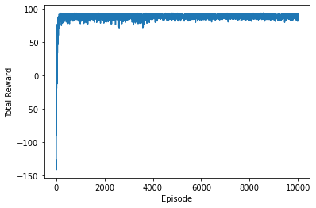

```python
plt.figure()
plt.plot(list(range(10000)), np.mean(np.array(steps_avgs), axis = 0))
plt.xlabel('Episode')
plt.ylabel('Number of steps to Goal')
plt.show()

plt.figure()
plt.plot(list(range(10000)), np.mean(np.array(reward_avgs), axis = 0))
plt.xlabel('Episode')
plt.ylabel('Total Reward')
plt.show()
```

### TODO: What differences do you observe between the policies learnt by Q Learning and SARSA (if any).

From the Q-value plots, it can be observed that Q-Learning exhibits a more aggressive behaviour as compared to SARSA which tends to be more conservative. This basically means that SARSA tends to be more risk averse in the sense that the regions giving negative rewards tend to get avoided a lot (essentially because it is on-policy learning), whereas in Q-Learning, since we are taking max over all actions (off-policy learning), the policy is usually more aggressive.

```python
!pip install nbconvert
!sudo apt-get install texlive-xetex texlive-fonts-recommended texlive-plain-generic
```

[output not shown]

[output cut: 310 more lines]

[output not shown]

```python
!jupyter nbconvert --to html "/content/drive/MyDrive/CS6700/CS6700_Tutorial_4_QLearning_SARSA/CS6700_Tutorial_4_QLearning_SARSA.ipynb"
```

```
[NbConvertApp] Converting notebook /content/drive/MyDrive/CS6700/CS6700_Tutorial_4_QLearning_SARSA/CS6700_Tutorial_4_QLearning_SARSA.ipynb to html
[NbConvertApp] Writing 790082 bytes to /content/drive/MyDrive/CS6700/CS6700_Tutorial_4_QLearning_SARSA/CS6700_Tutorial_4_QLearning_SARSA.html
```